# Tooth Growth on Guinea Pigs

mickfenneck

# Introduction

The project is meant to answer to this particular question:

> Now in the second portion of the class, we’re going to analyze the ToothGrowth data in the R datasets package.
> 1. Load the ToothGrowth data and perform some basic exploratory data analyses
> 2. Provide a basic summary of the data.
> 3. Use confidence intervals and hypothesis tests to compare tooth growth by supp and dose. (Use the techniques from class even if there’s other approaches worth considering)
> 4. State your conclusions and the assumptions needed for your conclusions.

# The Solution

### Analysis

We first have to give a look at the dataset and describe what is contained. Online you can find a quick description of the dataset:

Description The response is the length of odontoblasts (teeth) in each of 10 guinea pigs at each of three dose levels of Vitamin C (0.5, 1, and 2 mg) with each of two delivery methods (orange juice or ascorbic acid).

Format A data frame with 60 observations on 3 variables.

[,1] len numeric Tooth length

[,2] supp factor Supplement type (VC or OJ).

[,3] dose numeric Dose in milligrams.

```r
set.seed(1994)
data(ToothGrowth)
str(ToothGrowth)
```

```
## 'data.frame':    60 obs. of  3 variables:
##  $ len : num  4.2 11.5 7.3 5.8 6.4 10 11.2 11.2 5.2 7 ...
##  $ supp: Factor w/ 2 levels "OJ","VC": 2 2 2 2 2 2 2 2 2 2 ...
##  $ dose: num  0.5 0.5 0.5 0.5 0.5 0.5 0.5 0.5 0.5 0.5 ...
```

```r
summary(ToothGrowth)
```

```
##       len       supp         dose
##  Min.   : 4.2   OJ:30   Min.   :0.50
##  1st Qu.:13.1   VC:30   1st Qu.:0.50
##  Median :19.2           Median :1.00
##  Mean   :18.8           Mean   :1.17
##  3rd Qu.:25.3           3rd Qu.:2.00
##  Max.   :33.9           Max.   :2.00
```

```r
head(ToothGrowth)
```

```
##    len supp dose
## 1  4.2   VC  0.5
## 2 11.5   VC  0.5
## 3  7.3   VC  0.5
## 4  5.8   VC  0.5
## 5  6.4   VC  0.5
## 6 10.0   VC  0.5
```

We have a continuous dependent variable [len] and two independent variables, dose and suppliment, that are factors with 3 and 2 different treatment levels,

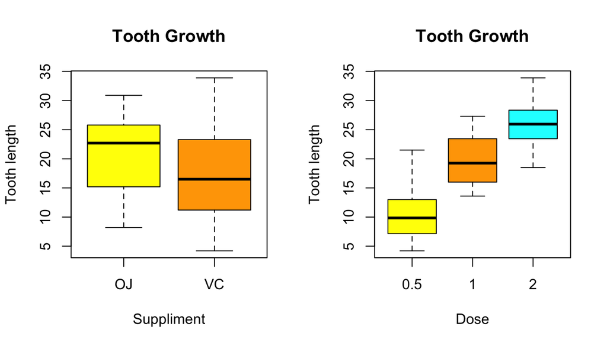

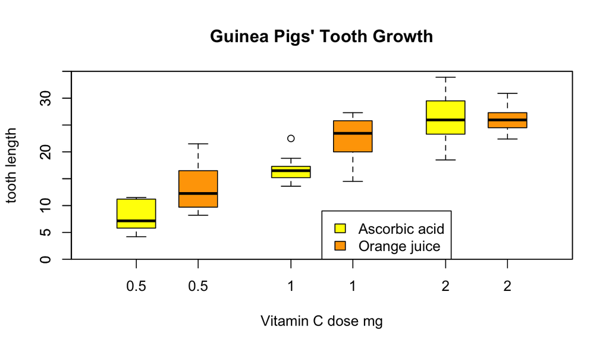

### Comparing Dosage Levels

Using the t.test function given by default we can display the t statistic values

```
##                      t    df   p-value conf interval sample estimates
## VC 1.0 vs 0.5:   7.463 17.86 6.811e-07 6.314, 11.266      16.77, 7.98
## VC 2.0 vs 1.0:   5.470 13.60 9.156e-05 5.686, 13.054     26.14, 16.77
## OJ 1.0 vs 0.5:   5.049 17.70 8.785e-05 5.524, 13.416      22.7, 13.23
## OJ 2.0 vs 1.0:   2.248 15.84 3.920e-02  0.189, 6.531      26.06, 22.7
```

The tables explains, as we should imagine, that ther is a correlation between the assumption of a major dosage and the growth of the teeth.

### Conclusion

We can finally state that the somministration of vitamine C in guinea pigs can determine an increase of the tooth growth in the animal.